# exercises_day4

Elisa

20 February 2019

# Problem 1

- are there repeated measurements, i.e. is there grouping so that data are not independent?
- how would you analyse these data to answer the research question?

### Solution

```r
growth <- read.delim("growth.txt")
```

This is a *factorial experiment* A factorial experiment has two or more factors, each with two or more levels, plus replication for each combination of factors levels. This means that we can investigate statistical interactions, in which the response to one factor depends on the level of another factor. Our example comes from a farm-scale trial of animal diets. There are two factors: diet and supplement.

- Diet: is a factor with three levels: barley, oats and wheat.
- Supplement: is a factor with four levels: agrimore, control, supergain and supersupp.
- Gain: The response variable is weight gain after 6 weeks.

We can inspect the means of each subgroup:

```r
attach(growth)
tapply(gain,list(diet,supplement),mean)
```

```
##        agrimore  control supergain supersupp
## barley 26.34848 23.29665  22.46612  25.57530
## oats   23.29838 20.49366  19.66300  21.86023
## wheat  19.63907 17.40552  17.01243  19.66834
```

```r
levels(diet)
```

```
## [1] "barley" "oats"   "wheat"
```

```r
levels(supplement)
```

```
## [1] "agrimore"  "control"   "supergain" "supersupp"
```

```r
detach(growth)
replications(gain~diet*supplement, growth)
```

```
##            diet      supplement diet:supplement
##              16              12               4
```

```r
replications(gain~diet*supplement, growth[1:20,])
```

```
## $diet
## diet
## barley   oats  wheat
##      0      4     16
##
## $supplement
## supplement
##  agrimore   control supergain supersupp
##         4         4         8         4
##
## $`diet:supplement`
##         supplement
## diet     agrimore control supergain supersupp
##   barley        0       0         0         0
##   oats          0       0         4         0
##   wheat         4       4         4         4
```

```r
xtabs(~ growth$diet+ growth$supplement)
```

```
##            growth$supplement
## growth$diet agrimore control supergain supersupp
##      barley        4       4         4         4
##      oats          4       4         4         4
##      wheat         4       4         4         4
```

Some examples to see how xtabs and replications works

```r
#We create a df
df <- data.frame(f1 = rep (c("a", "b"), each=10),
                 f2 = rep (c("ctr", "tr"), 10),
                 f3 =rep(c("big1","big2", "med", "small1", "small2"), 4),
                 response = rnorm(20,5,2))


#xtabs
xtabs(~ df$f1 + df$f2)
```

```
##      df$f2
## df$f1 ctr tr
##     a   5  5
##     b   5  5
```

```r
xtabs(~ df$f1 + df$f2 + df$f3)
```

```
## , , df$f3 = big1
##
##      df$f2
## df$f1 ctr tr
##     a   1  1
##     b   1  1
##
## , , df$f3 = big2
##
##      df$f2
## df$f1 ctr tr
##     a   1  1
##     b   1  1
##
## , , df$f3 = med
##
##      df$f2
## df$f1 ctr tr
##     a   1  1
##     b   1  1
##
## , , df$f3 = small1
##
##      df$f2
## df$f1 ctr tr
##     a   1  1
##     b   1  1
##
## , , df$f3 = small2
##
##      df$f2
## df$f1 ctr tr
##     a   1  1
##     b   1  1
```

```r
xtabs(~  df$f3 + df$f1 + df$f2)
```

```
## , , df$f2 = ctr
##
##         df$f1
## df$f3    a b
##   big1   1 1
##   big2   1 1
##   med    1 1
##   small1 1 1
##   small2 1 1
##
## , , df$f2 = tr
##
##         df$f1
## df$f3    a b
##   big1   1 1
##   big2   1 1
##   med    1 1
##   small1 1 1
##   small2 1 1
```

```r
#replications

replications(response ~ f1, data=df)
```

```
## f1
## 10
```

```r
replications(response ~ f2, data=df)
```

```
## f2
## 10
```

```r
replications(response ~ f3, data=df)
```

```
## f3
##  4
```

```r
replications(response ~ f1 + f2 + f3, data=df)
```

```
## f1 f2 f3
## 10 10  4
```

```r
replications(response ~ f1 * f2 * f3, data=df)
```

```
##       f1       f2       f3    f1:f2    f1:f3    f2:f3 f1:f2:f3
##       10       10        4        5        2        2        1
```

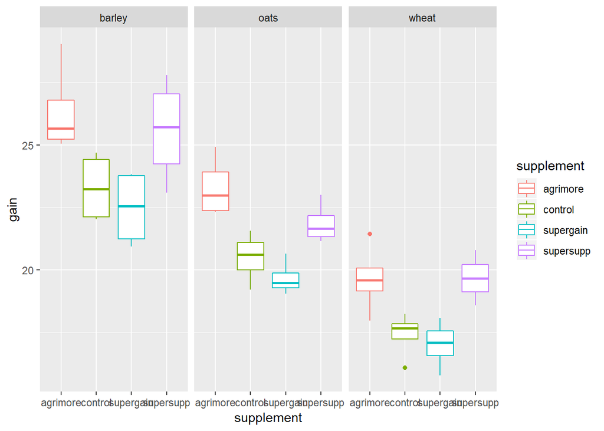

```r
growth %>% ggplot(aes(y=gain, x=supplement, colour=supplement))+
  geom_boxplot()+
 facet_grid(.~ diet)
```

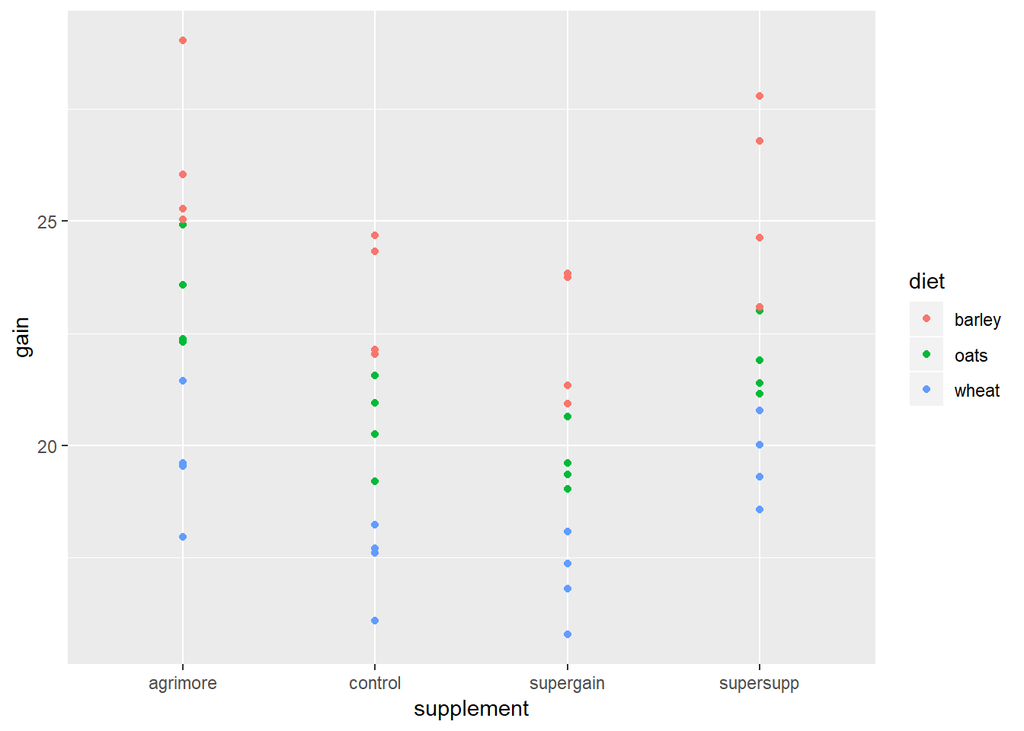

```r
growth %>%
  ggplot() +
  aes(y=gain, x=supplement, colour=diet) +
  geom_point(aes(group = supplement)) +
  geom_point()
```

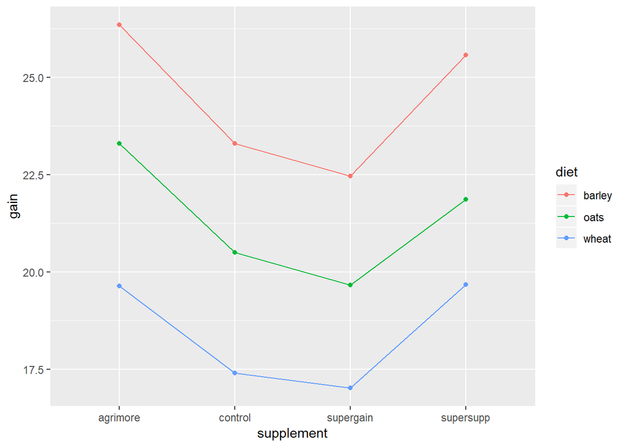

```r
growth %>%
  ggplot() +
  aes(x = supplement, color = diet, group = diet, y = gain) +
  stat_summary(fun.y = mean, geom = "point") +
  stat_summary(fun.y = mean, geom = "line")
```

Another example of plots not using ggplot

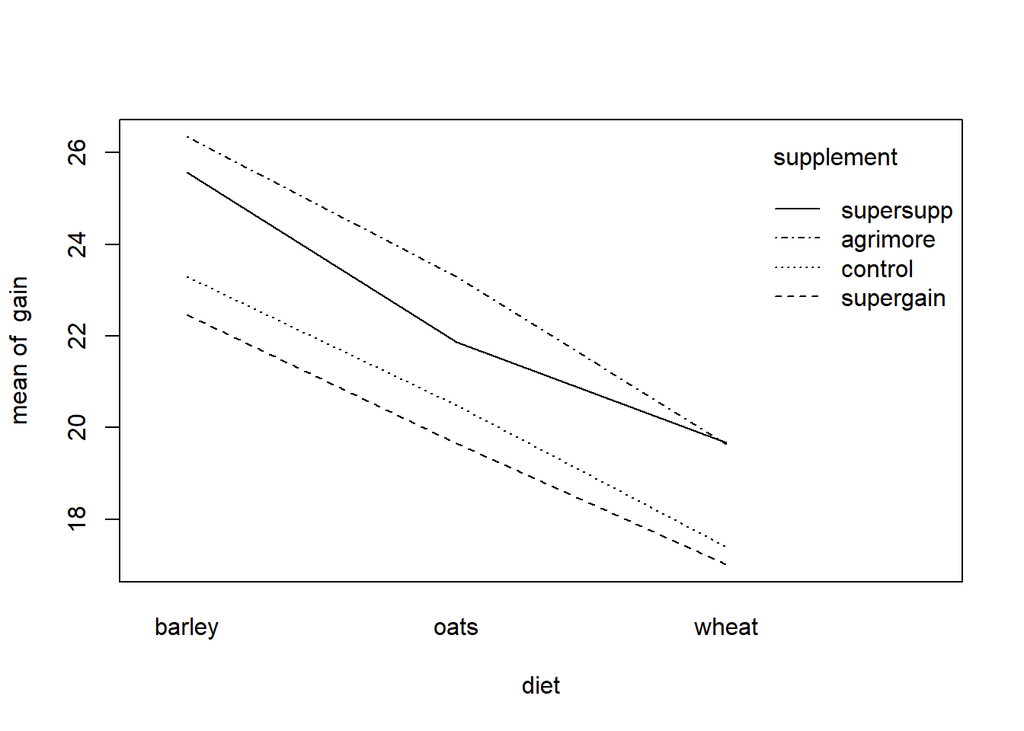

```r
attach(growth)
interaction.plot(diet, supplement, gain)
```

```r
detach(growth)
```

The experimental desing is balanced and there are no pseudoreplications. All meassurements are independent. Therefore, for two categorical variable and one numeric response i possible to use a two way ANOVA. We have to check that the reponse variable is normally distributet

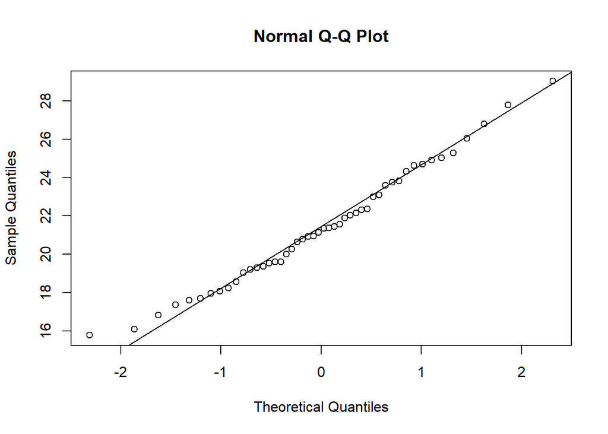

```r
a=2
qqnorm(y=growth$gain)
qqline(y=growth$gain)
```

```r
shapiro.test(growth$gain) # not significant so the data is normally distributet
```

```
##
##  Shapiro-Wilk normality test
##
## data:  growth$gain
## W = 0.98366, p-value = 0.7352
```

```r
library(car)
leveneTest(growth$gain, group = factor(paste0(growth$supplement, growth$diet)))
```

```
## Levene's Test for Homogeneity of Variance (center = median)
##       Df F value Pr(>F)
## group 11  1.1034 0.3866
##       36
```

Both tests are not signifficant which means that we are meeting the assumptions for the ANOVA: Equality of variances ammong groups and normal distr+ibution of response variable.

LetÂ´s do de analysis of the two way ANOVA

```r
attach(growth)
model1<-aov(gain~diet*supplement)
summary.lm(model1)
```

```
##
## Call:
## aov(formula = gain ~ diet * supplement)
##
## Residuals:
##      Min       1Q   Median       3Q      Max
## -2.48756 -1.00368 -0.07452  1.03496  2.68069
##
## Coefficients:
##                               Estimate Std. Error t value Pr(>|t|)
## (Intercept)                    26.3485     0.6556  40.191  < 2e-16 ***
## dietoats                       -3.0501     0.9271  -3.290 0.002248 **
## dietwheat                      -6.7094     0.9271  -7.237 1.61e-08 ***
## supplementcontrol              -3.0518     0.9271  -3.292 0.002237 **
## supplementsupergain            -3.8824     0.9271  -4.187 0.000174 ***
## supplementsupersupp            -0.7732     0.9271  -0.834 0.409816
## dietoats:supplementcontrol      0.2471     1.3112   0.188 0.851571
## dietwheat:supplementcontrol     0.8183     1.3112   0.624 0.536512
## dietoats:supplementsupergain    0.2470     1.3112   0.188 0.851652
## dietwheat:supplementsupergain   1.2557     1.3112   0.958 0.344601
## dietoats:supplementsupersupp   -0.6650     1.3112  -0.507 0.615135
## dietwheat:supplementsupersupp   0.8024     1.3112   0.612 0.544381
## ---
## Signif. codes:  0 '***' 0.001 '**' 0.01 '*' 0.05 '.' 0.1 ' ' 1
##
## Residual standard error: 1.311 on 36 degrees of freedom
## Multiple R-squared:  0.8607, Adjusted R-squared:  0.8182
## F-statistic: 20.22 on 11 and 36 DF,  p-value: 3.295e-12
```

```r
model2<-aov(gain~diet + supplement)
summary.lm(model2)
```

```
##
## Call:
## aov(formula = gain ~ diet + supplement)
##
## Residuals:
##      Min       1Q   Median       3Q      Max
## -2.30792 -0.85929 -0.07713  0.92052  2.90615
##
## Coefficients:
##                     Estimate Std. Error t value Pr(>|t|)
## (Intercept)          26.1230     0.4408  59.258  < 2e-16 ***
## dietoats             -3.0928     0.4408  -7.016 1.38e-08 ***
## dietwheat            -5.9903     0.4408 -13.589  < 2e-16 ***
## supplementcontrol    -2.6967     0.5090  -5.298 4.03e-06 ***
## supplementsupergain  -3.3815     0.5090  -6.643 4.72e-08 ***
## supplementsupersupp  -0.7274     0.5090  -1.429     0.16
## ---
## Signif. codes:  0 '***' 0.001 '**' 0.01 '*' 0.05 '.' 0.1 ' ' 1
##
## Residual standard error: 1.247 on 42 degrees of freedom
## Multiple R-squared:  0.8531, Adjusted R-squared:  0.8356
## F-statistic: 48.76 on 5 and 42 DF,  p-value: < 2.2e-16
```

It is clear that we need to retain all three levels of diet (oats differ from wheat by 5.99???3.09 = 2.90 with a standard error of 0.44). It is not clear that we need four levels of supplement, however. Supersupp is not obviously different from agrimore (0.727 with standard error 0.509). Nor is supergain obviously different from the unsupplemented control animals 3.38???2.70=0.68. We shall try a new two-level factor to replace the four-level supplement, and see if this significantly reduces the model’s explanatory power. Agrimore and supersupp are recoded as best and control and supergain as worst:

```r
supp2<-factor(supplement)
levels(supp2)
```

```
## [1] "agrimore"  "control"   "supergain" "supersupp"
```

```r
levels(supp2)[c(1,4)]<-"best"
levels(supp2)[c(2,3)]<-"worst"
levels(supp2)
```

```
## [1] "best"  "worst"
```

```r
model3<-aov(gain~diet+supp2)
anova(model1,model3)
```

```
## Analysis of Variance Table
##
## Model 1: gain ~ diet * supplement
## Model 2: gain ~ diet + supp2
##   Res.Df    RSS Df Sum of Sq     F Pr(>F)
## 1     36 61.890
## 2     44 71.284 -8   -9.3934 0.683 0.7034
```

```r
detach(growth)
```

# Problem 2

Load the data set “farms.txt”. In it, the plant size (“size”) of plants has been several times 5 times on each of 24 sites (“farms”). At the same spot the nitrogen concentration in the soil has been recorded (“N”). The question is, how plant size changes as nitrogen concentration changes. - again, spot the grouping. Where is the pseudo-correlation? Is it temporal or spatial? Are the data balanced? - analyse the data to answer the research question using R.

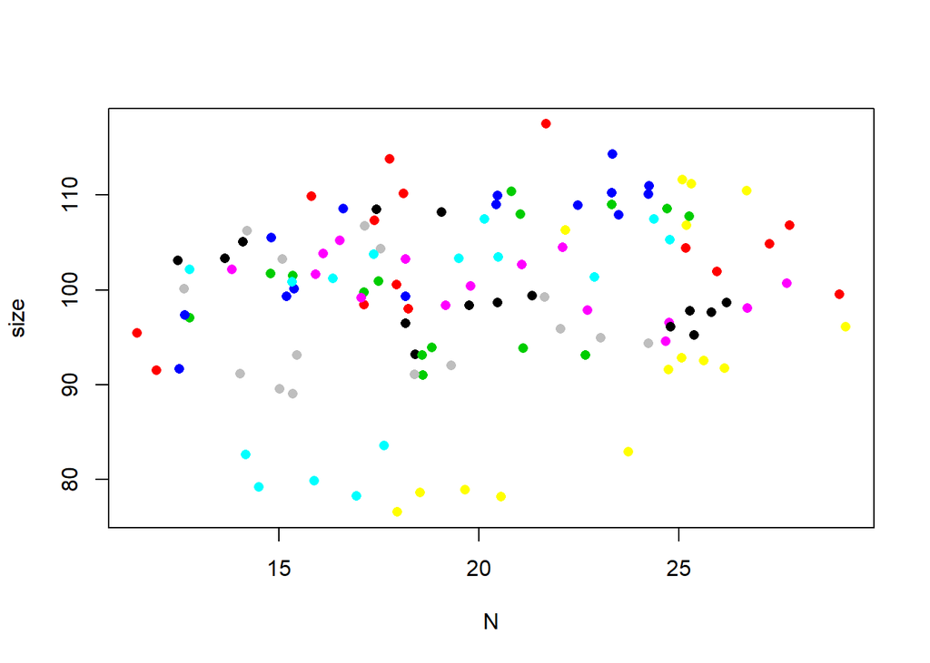

```r
farms <- read.delim("farms.txt")

with(farms, (plot(N,size,pch=16,col=farm))) # quick plot to inspect data
```

```r
xtabs(~farms$farm) # check for balance design
```

```
## farms$farm
##  1  2  3  4  5  6  7  8  9 10 11 12 13 14 15 16 17 18 19 20 21 22 23 24
##  5  5  5  5  5  5  5  5  5  5  5  5  5  5  5  5  5  5  5  5  5  5  5  5
```

```r
unique(is.na(farms$N)) # check for nas
```

```
## [1] FALSE
```

```r
unique(is.na(farms$size)) # check for nas
```

```
## [1] FALSE
```

Then, we have a balance experimental design with no nas.

We can use a lm:

```r
attach(farms)
model1<-lm(size~N+factor(farm)) # same slope but different intercepts
model2<-lm(size~N*factor(farm)) # different slopes but different intercepts -- too many parameters
model3<- lm(size~factor(farm))

anova(model1, model2, model3)
```

```
## Analysis of Variance Table
##
## Model 1: size ~ N + factor(farm)
## Model 2: size ~ N * factor(farm)
## Model 3: size ~ factor(farm)
##   Res.Df    RSS  Df Sum of Sq      F    Pr(>F)
## 1     95 353.81
## 2     72 281.60  23    72.212 0.8028 0.7169670
## 3     96 573.04 -24  -291.447 3.1049 0.0001104 ***
## ---
## Signif. codes:  0 '***' 0.001 '**' 0.01 '*' 0.05 '.' 0.1 ' ' 1
```

```r
detach(farms)
```

This might make you think that the meassurements in each farm are correlated. Actually, farm is not something we are intrested in. It is a random effect. And, measurements inside one farm are not independent We can model the error using the error term when specifying the anova. This is, we can do an ANOVA with hyerarchical design.

```r
mod.aov.1 <- aov(size ~ N + Error(farm), farms)
mod.aov.2 <- aov(size ~ N + Error(farm/N), farms)
```

But which is the problem here, well, N is not a categorical variable. It is fitting intercepts and the same slope for all the farms. It can not be used to fit different slopes per farm. We could do that adding interactions to a lm but we could not add the structure of the error. And thatÂ´s where we need mixed models.

LetÂ´s make one linear model per farm, this is seen in many papers

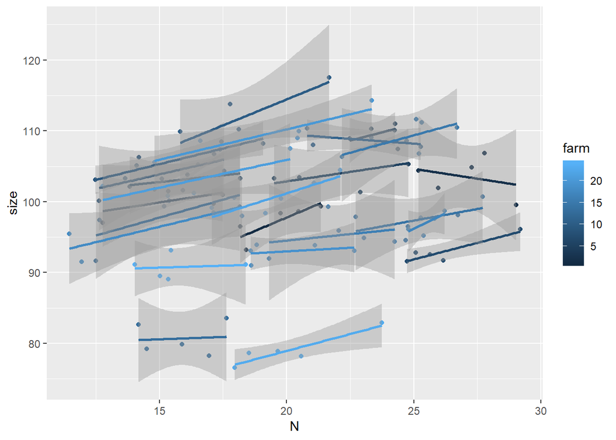

```r
ggplot(farms, aes(x= N, y=size, group = farm, color= farm))+
    geom_point()+
    geom_smooth(method=lm, se=TRUE)
```

# Problem 3

load the data set “artemisia.txt”. It describes how the plant Artimisa maritima growth under low (0) and high (1) competition and under absence (0) and presence (1) of nematodes. This is a 2 x 2 factorial design with 2 treatments, each with 2 levels.

- again: is there any form of grouping? What is it?
- should you run a repeated measurement ANOVA? If no, why not?
- try it!
- why does the output differ between “mod <- aov(Artemisia ~ comp * nematodes + Error(as.factor(block)), artemisia)” and mod <- aov(Artemisia ~ comp * nematodes + Error(block), artemisia)

## Solutions

```r
artemisa <- read.delim("artemisia.txt")
artemisa$comp <- factor(artemisa$comp)
artemisa$nematodes <- factor(artemisa$nematodes)
artemisa$block <- factor(artemisa$block)
artemisa <- artemisa[1:52,]
with(artemisa, (xtabs(~comp+nematodes)))
```

```
##     nematodes
## comp  0  1
##    0 11 10
##    1 16 14
```

We have a non-balance design. We also have the variable block that might be a grouping factor. Running a repeated measurement ANOVA is a problem because the experimental design is umbalanced.

Some more things that show how messy is this data

```r
replications(Artemisia~ nematodes*comp, data=artemisa)
```

```
## $nematodes
## nematodes
##  0  1
## 27 22
##
## $comp
## comp
##  0  1
## 19 30
##
## $`nematodes:comp`
##          comp
## nematodes  0  1
##         0 11 16
##         1  8 14
```

```r
replications(Artemisia~ nematodes*comp*block, data=artemisa)
```

```
## $nematodes
## nematodes
##  0  1
## 27 22
##
## $comp
## comp
##  0  1
## 19 30
##
## $block
## block
##  1  2  3  4  5  6  7  8  9 10 11 12 13 14 15 16
##  3  3  4  3  3  4  3  4  3  3  3  3  3  2  3  2
##
## $`nematodes:comp`
##          comp
## nematodes  0  1
##         0 11 16
##         1  8 14
##
## $`nematodes:block`
##          block
## nematodes 1 2 3 4 5 6 7 8 9 10 11 12 13 14 15 16
##         0 2 2 2 2 2 2 2 2 1  2  1  2  1  2  1  1
##         1 1 1 2 1 1 2 1 2 2  1  2  1  2  0  2  1
##
## $`comp:block`
##     block
## comp 1 2 3 4 5 6 7 8 9 10 11 12 13 14 15 16
##    0 1 1 2 1 1 2 1 2 1  1  1  1  1  1  1  1
##    1 2 2 2 2 2 2 2 2 2  2  2  2  2  1  2  1
##
## $`nematodes:comp:block`
## , , block = 1
##
##          comp
## nematodes 0 1
##         0 1 1
##         1 0 1
```

[output cut: 90 more lines]

```
##         1 0 0
##
## , , block = 15
##
##          comp
## nematodes 0 1
##         0 0 1
##         1 1 1
##
## , , block = 16
##
##          comp
## nematodes 0 1
##         0 0 1
##         1 1 0
```

```r
aov(Artemisia ~ comp *nematodes, data= artemisa)
```

```
## Call:
##    aov(formula = Artemisia ~ comp * nematodes, data = artemisa)
##
## Terms:
##                      comp nematodes comp:nematodes Residuals
## Sum of Squares  1888.5157    0.9984         2.6095  341.4886
## Deg. of Freedom         1         1              1        45
##
## Residual standard error: 2.754748
## Estimated effects may be unbalanced
## 3 observations deleted due to missingness
```

```r
attach(artemisa)
mod <- aov(Artemisia ~ comp * nematodes + Error(as.factor(block)))
summary(mod)
```

```
##
## Error: as.factor(block)
##                Df Sum Sq Mean Sq F value Pr(>F)
## comp            1  22.35  22.352   2.002  0.183
## nematodes       1   0.01   0.013   0.001  0.973
## comp:nematodes  1   0.33   0.331   0.030  0.866
## Residuals      12 133.98  11.165
##
## Error: Within
##                Df Sum Sq Mean Sq F value Pr(>F)
## comp            1 1871.3  1871.3 277.774 <2e-16 ***
## nematodes       1    1.3     1.3   0.186  0.670
## comp:nematodes  1    2.3     2.3   0.335  0.567
## Residuals      30  202.1     6.7
## ---
## Signif. codes:  0 '***' 0.001 '**' 0.01 '*' 0.05 '.' 0.1 ' ' 1
```

```r
detach(artemisa)
```

# Notes

## Split-plot design

In a split-plot experiment, different treatments are applied to plots of different sizes. Each different plot size is associated with its own error variance.

The error structure is defined in the Error term, with the plot sizes listed from left to right, from largest to smallest, with each variable separated by the slash operator /. The smallest plot size, fertilizer, does not need to appear in the Error term.

Block is not a fixed effect, we are non intrested in it, it si a random effect and this it only appear in the error temr.

```r
yields <- read.delim("splityield.txt")
attach(yields)
model<-aov(yield~irrigation*density*fertilizer +Error(block/irrigation/density))


summary(model)
```

```
##
## Error: block
##           Df Sum Sq Mean Sq F value Pr(>F)
## Residuals  3  194.4   64.81
##
## Error: block:irrigation
##            Df Sum Sq Mean Sq F value Pr(>F)
## irrigation  1   8278    8278   17.59 0.0247 *
## Residuals   3   1412     471
## ---
## Signif. codes:  0 '***' 0.001 '**' 0.01 '*' 0.05 '.' 0.1 ' ' 1
##
## Error: block:irrigation:density
##                    Df Sum Sq Mean Sq F value Pr(>F)
## density             2   1758   879.2   3.784 0.0532 .
## irrigation:density  2   2747  1373.5   5.912 0.0163 *
## Residuals          12   2788   232.3
## ---
## Signif. codes:  0 '***' 0.001 '**' 0.01 '*' 0.05 '.' 0.1 ' ' 1
##
## Error: Within
##                               Df Sum Sq Mean Sq F value   Pr(>F)
## fertilizer                     2 1977.4   988.7  11.449 0.000142 ***
## irrigation:fertilizer          2  953.4   476.7   5.520 0.008108 **
## density:fertilizer             4  304.9    76.2   0.883 0.484053
## irrigation:density:fertilizer  4  234.7    58.7   0.680 0.610667
## Residuals                     36 3108.8    86.4
## ---
## Signif. codes:  0 '***' 0.001 '**' 0.01 '*' 0.05 '.' 0.1 ' ' 1
```

```r
detach(yields)
```

So, how do we interprete this table.

- Error: block This is the MS of blocks. That is, the difference between the mean of the blobks and the grand mean
- Error : block : irrigation This is the MS of the group irrigation (each irrigation group mean - mean of the block ) / MS inside the group (each value - mean of the subgroup irrigation)
- Error: block : irrigation : density The MS of sub-sub-group density (the mean of the sub-sub group - the mean of the group to which it corresponds) / MS within each density group (each value of the sub-sub-group minus the mean of the corresponding sub-sub group)
- Error: within Results for the smaller sub-sub-sub group. fertilizer . MS of the group (the mean of each sub-sub-sub group minus the mean fo the sub sub grout to which it corresponds)

And the interactions

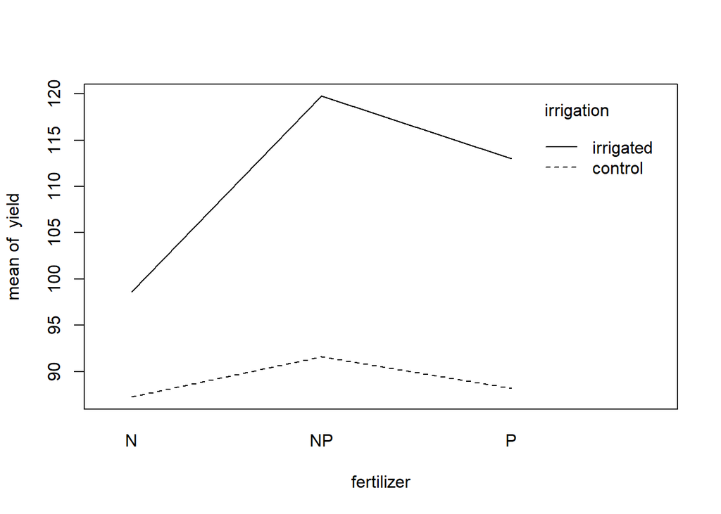

```r
attach(yields)

interaction.plot(fertilizer,irrigation,yield)
```

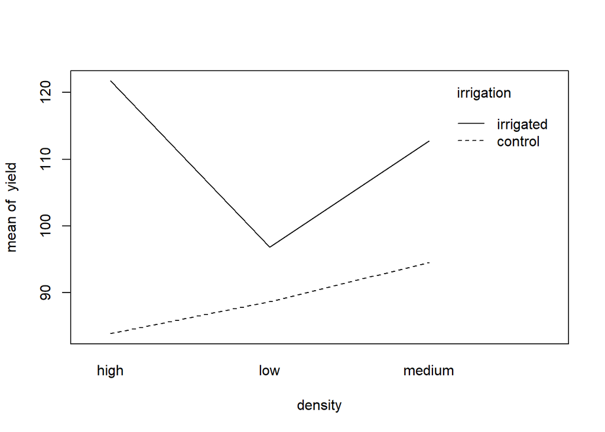

```r
interaction.plot(density,irrigation,yield)
```

```r
detach(yields)
```

# Repeated measurements along time

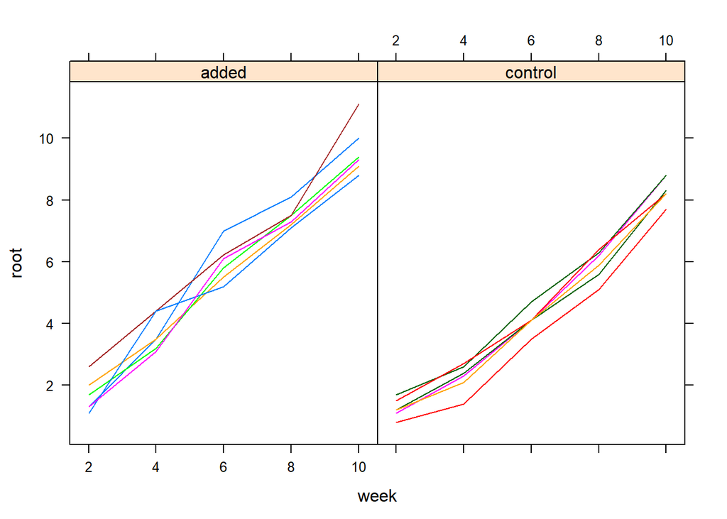

```r
fertilizer <- read.delim("fertilizer.txt")
library(lattice)
xyplot(root ~ week|fertilizer, group = plant, fertilizer, type = "l") #the lattice package for easy plotting of grouped data
```

Or ggplot

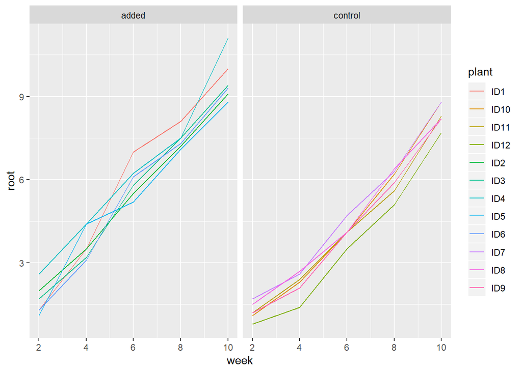

```r
library(ggplot2)
library(dplyr)
library(tidyr)
fertilizer %>% ggplot(aes(x=week, y=root, colour=plant)) +
  geom_line() +
  facet_grid(.~ fertilizer )
```

```r
rm.fertilizer <- aov(root ~ week * fertilizer + Error(plant/week), fertilizer)
summary(rm.fertilizer)
```

```
##
## Error: plant
##            Df Sum Sq Mean Sq F value   Pr(>F)
## fertilizer  1 25.650  25.650   33.06 0.000185 ***
## Residuals  10  7.758   0.776
## ---
## Signif. codes:  0 '***' 0.001 '**' 0.01 '*' 0.05 '.' 0.1 ' ' 1
##
## Error: plant:week
##                 Df Sum Sq Mean Sq F value   Pr(>F)
## week             1  421.9   421.9 2912.16 1.16e-13 ***
## week:fertilizer  1    1.0     1.0    6.96   0.0248 *
## Residuals       10    1.4     0.1
## ---
## Signif. codes:  0 '***' 0.001 '**' 0.01 '*' 0.05 '.' 0.1 ' ' 1
##
## Error: Within
##           Df Sum Sq Mean Sq F value Pr(>F)
## Residuals 36  8.879  0.2466
```

```r
proj(rm.fertilizer)[1] # global intercept
```

```
## (Intercept) :
##    (Intercept)
## 1     5.023833
## 2     5.023833
## 3     5.023833
## 4     5.023833
## 5     5.023833
## 6     5.023833
## 7     5.023833
## 8     5.023833
## 9     5.023833
## 10    5.023833
## 11    5.023833
## 12    5.023833
## 13    5.023833
```

[output cut: 59 more lines]

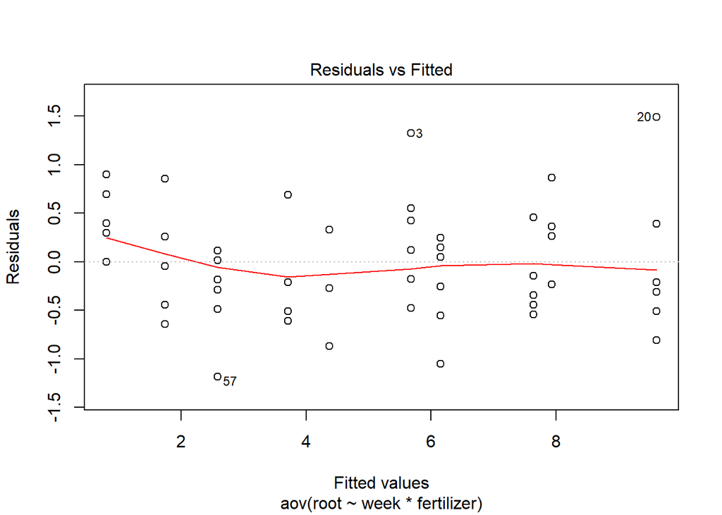

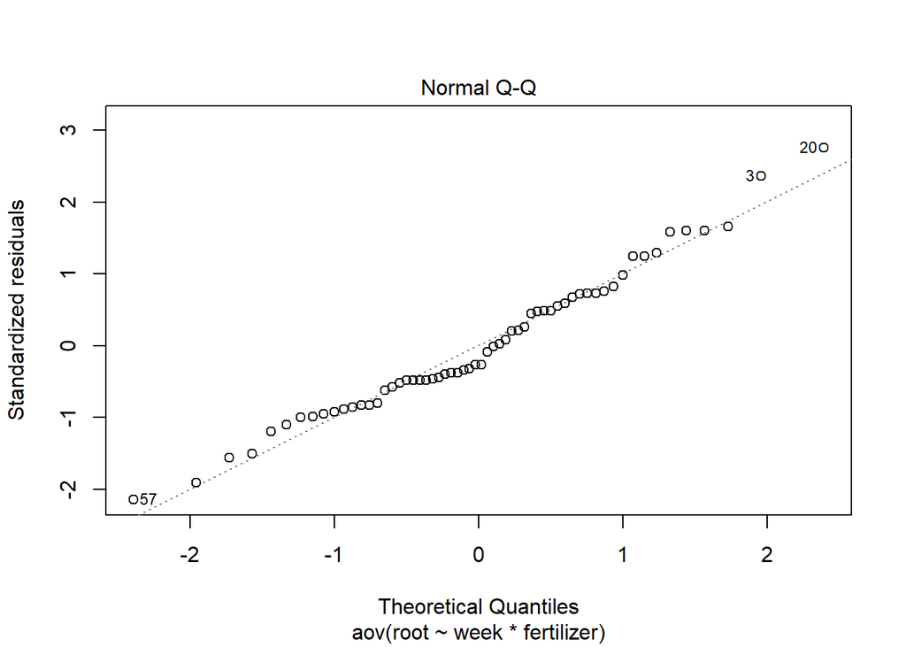

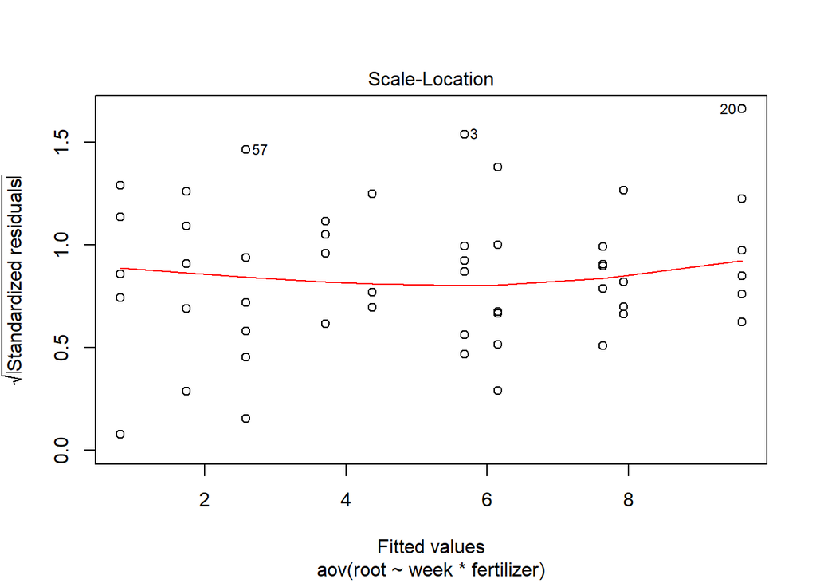

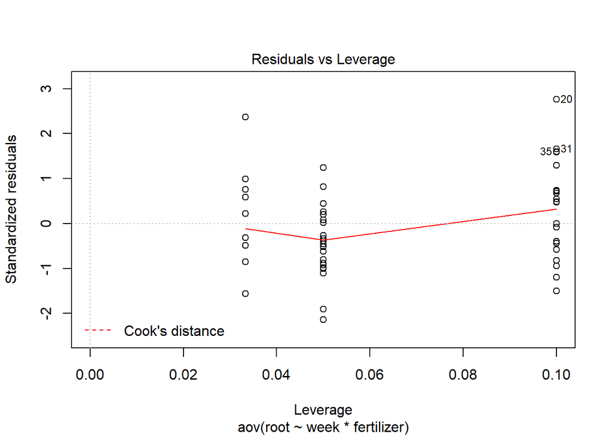

```r
plot(aov(root ~ week * fertilizer , fertilizer))
```